# Lesson 5

Jose Alcocer

## 5.0 Data Wrangling + Text Analysis

Very rarely in data science, data is easily available as part of a package or download. Much more typical is for the data to be in a file, a database, or extracted from a document, including web pages, tweets, or PDFs. In these cases, the first step is to import the data into R and, when using the tidyverse package, *tidy* the data. This initial step in the data analysis process usually involves a lot of steps to convert the obtained data from its raw form to the *tidy* form that greatly facilitates the rest of the analysis. The entirety of this process can be referred to as data wrangling. This lesson will therefore focus on conducting some of these steps. The latter part of the lesson will briefly introduce text analysis and how it is possible to use R to analyses multiple strings of data.

## 5.1 Reshaping Data

The following code prepares the environment necessary to learn how to reshape a dataset

```r
# Download required packages
# install.packages("dslabs")
library(tidyverse)
library(dslabs)

# Creating object that extracts the example dataset we will use
path <- system.file("extdata", package="dslabs")
filename <- file.path(path, "fertility-two-countries-example.csv")
wide_data <- read_csv(filename)
# Looking at the data
wide_data
```

```
## # A tibble: 2 × 57
##   country  `1960` `1961` `1962` `1963` `1964` `1965` `1966` `1967` `1968` `1969`
##   <chr>     <dbl>  <dbl>  <dbl>  <dbl>  <dbl>  <dbl>  <dbl>  <dbl>  <dbl>  <dbl>
## 1 Germany    2.41   2.44   2.47   2.49   2.49   2.48   2.44   2.37   2.28   2.17
## 2 South K…   6.16   5.99   5.79   5.57   5.36   5.16   4.99   4.85   4.73   4.62
## # … with 46 more variables: `1970` <dbl>, `1971` <dbl>, `1972` <dbl>,
## #   `1973` <dbl>, `1974` <dbl>, `1975` <dbl>, `1976` <dbl>, `1977` <dbl>,
## #   `1978` <dbl>, `1979` <dbl>, `1980` <dbl>, `1981` <dbl>, `1982` <dbl>,
## #   `1983` <dbl>, `1984` <dbl>, `1985` <dbl>, `1986` <dbl>, `1987` <dbl>,
## #   `1988` <dbl>, `1989` <dbl>, `1990` <dbl>, `1991` <dbl>, `1992` <dbl>,
## #   `1993` <dbl>, `1994` <dbl>, `1995` <dbl>, `1996` <dbl>, `1997` <dbl>,
## #   `1998` <dbl>, `1999` <dbl>, `2000` <dbl>, `2001` <dbl>, `2002` <dbl>, …
## # ℹ Use `colnames()` to see all variable names
```

One of the most used functions in the tidyr package is **pivot_longer**, which is useful for converting wide data into tidy data. The **pivot_longer** function’s first argument is the data frame that will be converted. Here we want to reshape the wide_data dataset so that each row represents a fertility observation, which implies we need three columns to store the year, country, and the observed value. In its current form, data from different years are in different columns with the year values stored in the column names. Through the **names_to** and **values_to** argument, we will tell **pivot_longer** the column names we want to assign to the columns containing the current column names and observations, respectively. The code to do this will look like the following

```r
data <- pivot_longer(wide_data, `1960`:`2015`, names_to = "year", values_to = "fertility")

# Looking at the new data, we can see how it has been reformatted to tidy format
head(data)
```

```
## # A tibble: 6 × 3
##   country year  fertility
##   <chr>   <chr>     <dbl>
## 1 Germany 1960       2.41
## 2 Germany 1961       2.44
## 3 Germany 1962       2.47
## 4 Germany 1963       2.49
## 5 Germany 1964       2.49
## 6 Germany 1965       2.48
```

If we were to try to plot this data using ggplot, we would see that it is not fully successful as our new data frame has the years sorted out as characters of text. It is important to check the data classes of a dataset that is being wrangled in order to ensure that it is classified correctly. If it is not, then you can do something about it to correct it

```r
# Checking data types for all variables in data set
class(data$year) # gives us character = not good
```

```
## [1] "character"
```

```r
class(data$country) # gives us character = good
```

```
## [1] "character"
```

```r
class(data$fertility) # gives us numeric = good
```

```
## [1] "numeric"
```

In order to correct the year variable, we can convert character strings into integers with the following code

```r
# converting variable into integer type
data$year <- as.integer(data$year)

# verifying
class(data$year)
```

```
## [1] "integer"
```

Once we did this, then we can proceed to plot the data successfully

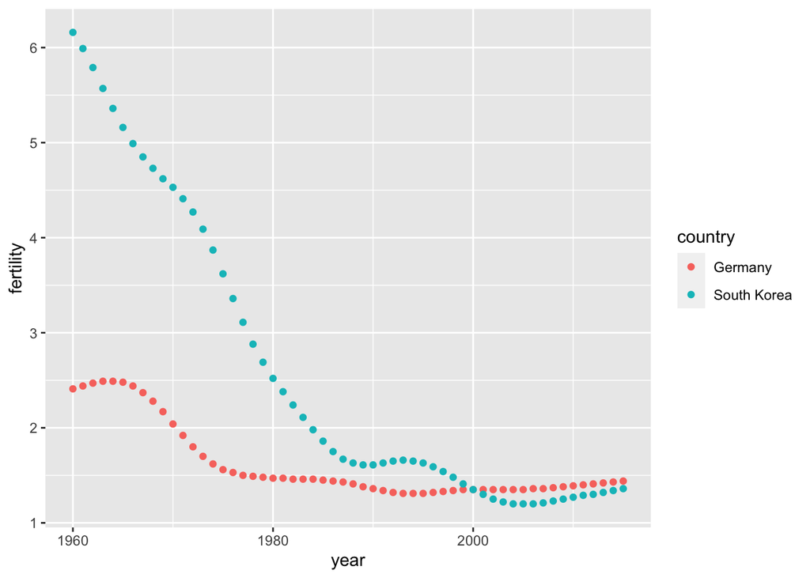

```r
data |> ggplot(aes(year, fertility, color = country)) +
  geom_point()
```

If we want to turn tidy data into wide format (sometimes we may want to actually do this), then we can use the **pivot_wider** function. This function does the inverse of the **pivot_longer** one

```r
wide_data <- data |>
  pivot_wider(names_from = year, values_from = fertility)
select(wide_data, country, `1960`:`1967`)
```

```
## # A tibble: 2 × 9
##   country     `1960` `1961` `1962` `1963` `1964` `1965` `1966` `1967`
##   <chr>        <dbl>  <dbl>  <dbl>  <dbl>  <dbl>  <dbl>  <dbl>  <dbl>
## 1 Germany       2.41   2.44   2.47   2.49   2.49   2.48   2.44   2.37
## 2 South Korea   6.16   5.99   5.79   5.57   5.36   5.16   4.99   4.85
```

The following example will deal with the same dataset formatted in a way that is very unpractical and often realistic. Here, we will have to separate the data so that it becomes optimally stored

```r
path <- system.file("extdata", package = "dslabs")

filename <- "life-expectancy-and-fertility-two-countries-example.csv"
filename <-  file.path(path, filename)

raw_dat <- read_csv(filename)
select(raw_dat, 1:5)
```

```
## # A tibble: 2 × 5
##   country     `1960_fertility` `1960_life_expectancy` `1961_fertility` 1961_li…¹
##   <chr>                  <dbl>                  <dbl>            <dbl>     <dbl>
## 1 Germany                 2.41                   69.3             2.44      69.8
## 2 South Korea             6.16                   53.0             5.99      53.8
## # … with abbreviated variable name ¹`1961_life_expectancy`
```

As you can see, the columns have the variable names and are placed in a very awkward direction that it would be difficult to analyze effectively

```r
# converting wide data into tidy format
data <- raw_dat |> pivot_longer(-country)
head(data)
```

```
## # A tibble: 6 × 3
##   country name                 value
##   <chr>   <chr>                <dbl>
## 1 Germany 1960_fertility        2.41
## 2 Germany 1960_life_expectancy 69.3
## 3 Germany 1961_fertility        2.44
## 4 Germany 1961_life_expectancy 69.8
## 5 Germany 1962_fertility        2.47
## 6 Germany 1962_life_expectancy 70.0
```

```r
# we can see that the name variable has both a year and type of value
# the following code can be used to correctly separate both names from that name variable into two separate ones

newer_data <- data |> separate(name, c("year", "name"), extra = "merge")
```

Now, we need to create a column for each variable. As we learned, the **pivot_wider** function can do this

```r
# running the same line of code above but altogether with the pivot_wider function
newer_data <- data |>
  separate(name, c("year", "name"), extra = "merge") |>
  pivot_wider()
```